# PROJECT: APPLIED STATISTICS

## PART 1

```python
import numpy as np
import pandas as pd
import matplotlib.pyplot as plt
import scipy.stats as stats
import seaborn as sns
import math
```

```python
#Solution 1
```

```python
plan_purch= 400
total= 2000
jointp= (plan_purch/total)
print ('Joint probability of people who planned, and purchased the product is',jointp)

totalplanned= 500
jointp2= (plan_purch/totalplanned)
print ('Joint probability of people who planned, and purchased the product, given they planned is',jointp2)
```

```
Joint probability of people who planned, and purchased the product is 0.2
Joint probability of people who planned, and purchased the product, given they planned is 0.8
```

```python
#Solution 2
```

```python
k=np.arange(0,11)
n=10
p=0.05

binom= stats.binom.pmf(k,n,p).round(4)
binom2= stats.binom.cdf([2],n,p).round(4)

print ('Ans.a: Probability of none of the bulbs were deffected is ',binom[0])
print ('Ans.b: Probability of exactly One of the bulbs were deffected is', binom[1])
print ('Ans.c: Probability that two or fewer of the items are defective is', binom2 )
print ('Ans.d: Probability that three or more of the items are defective is', 1-binom2)
```

```
Ans.a: Probability of none of the bulbs were deffected is  0.5987
Ans.b: Probability of exactly One of the bulbs were deffected is 0.3151
Ans.c: Probability that two or fewer of the items are defective is [0.9885]
Ans.d: Probability that three or more of the items are defective is [0.0115]
```

```python
#Solution 3
```

```
A: Probability that in a given week he will sell some cars is 0.9502
B: Probability that in a given week he will sell some cars is 0.6161
```

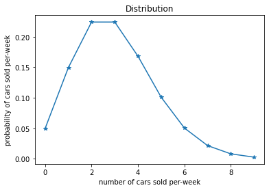

```python
n= np.arange(0,10)
rate=3

prob=stats.poisson.cdf(n,rate)
prob1=1-prob[0]
print('A: Probability that in a given week he will sell some cars is %1.4f' % prob1 )


prob2= stats.poisson.pmf([2,3,4],rate).sum()
print('B: Probability that in a given week he will sell some cars is %1.4f' % prob2 )

prob3=stats.poisson.pmf(n,rate,)
plt.plot(n,prob3,'*-')
plt.title('Distribution')
plt.xlabel('number of cars sold per-week')
plt.ylabel('probability of cars sold per-week')
plt.show()
```

```python
#Solution 4
```

```python
n=3
x=3
p=0.868
q=1-p
ncx= math.factorial(n)/(math.factorial(x)*math.factorial(n-x))
px=p**x
qx=q**(n-x)
Px3= ncx*px*qx

n=3
x=0
p=0.868
q=1-p
ncx= math.factorial(n)/(math.factorial(x)*math.factorial(n-x))
px=p**x
qx=q**(n-x)
Px0= ncx*px*qx

n=3
x=2
p=0.868
q=1-p
ncx= math.factorial(n)/(math.factorial(x)*math.factorial(n-x))
px=p**x
qx=q**(n-x)
Px2= ncx*px*qx
Px23=Px2+Px3

print ('A: Probability that all three orders will be recognised correctly is %1.4f' %Px3)
print ('B: Probability that none of orders will be recognised correctly is %1.4f' %Px0)
print ('C: Probability that at least two of three orders will be recognised correctly is %1.4f' %Px23)
```

```
A: Probability that all three orders will be recognised correctly is 0.6540
B: Probability that none of orders will be recognised correctly is 0.0023
C: Probability that at least two of three orders will be recognised correctly is 0.9523
```

```python
#Solution 5
```

```python
x= 80
mu=60
std=12
z=round((x-mu)/std,4)
zval0= 0.5      #Zvalue of 0
zval1= 0.4525   #Zvalue of 1.67, seen from Z table
ans= (zval0-zval1)*100    #multiplied by 100 to get value in percentage format.

x= 50
mu=60
std=12
z2=round((x-mu)/std,4)
zval0= 0.5      #Zvalue of 0
zval1= 0.2967   #Zvalue of 0.8333, seen from Z table
ans2= (zval0-zval1)*100    #multiplied by 100 to get value in percentage format.

x= 50
mu=60
std=12
z2=round((x-mu)/std,4)
zval0= 0.5      #Zvalue of 0
zval1= 0.2967   #Zvalue of 0.8333, seen from Z table
ans2= (zval0-zval1)*100    #multiplied by 100 to get value in percentage format.
print ('A: Percentage of students who score more than 80 is %1.2f' %ans, '%')
print ('B: Percentage of students who score more than 80 is %1.2f' %ans2, '%')


#Using Z table we can find that value for 0.40(0.3997) is 1.28
z=1.28
x= 50
mu=60
std=12

x=(z*std)+mu
print ('C: distinction mark of the highest 10% of students should be',x,'%')
```

[output not shown]

```python
#Solution 6
```

Some example Scenarios:

```
1. We can use these techniques to assess the success and failure rate  decisions made by an automated vehicle to find the probability of the vecicle taking decisions correctly.

2. We can use these techniques to see if the employees of a certain company is reaching its targets or not, and what is the probability of him making improvement.

3. We can also use the techniques to seggregate students appearing for any exam, such as students appearing for Great Learning project, get the percentage of students in the top 10% and award them with 'Star performer' Awards.
```

## PART 2

```python
import numpy as np
import pandas as pd
import matplotlib.pyplot as plt
import scipy.stats as stats
import seaborn as sns
import math
```

# PART TWO: Project Based

```python
data=pd.read_csv('DS - Part2 - Basketball.csv')
data.head()
```

|  | Team | Tournament | Score | PlayedGames | WonGames | DrawnGames | LostGames | BasketScored | BasketGiven | TournamentChampion | Runner-up | TeamLaunch | HighestPositionHeld |
| --- | --- | --- | --- | --- | --- | --- | --- | --- | --- | --- | --- | --- | --- |
| 0 | Team 1 | 86 | 4385 | 2762 | 1647 | 552 | 563 | 5947 | 3140 | 33 | 23 | 1929 | 1 |
| 1 | Team 2 | 86 | 4262 | 2762 | 1581 | 573 | 608 | 5900 | 3114 | 25 | 25 | 1929 | 1 |
| 2 | Team 3 | 80 | 3442 | 2614 | 1241 | 598 | 775 | 4534 | 3309 | 10 | 8 | 1929 | 1 |
| 3 | Team 4 | 82 | 3386 | 2664 | 1187 | 616 | 861 | 4398 | 3469 | 6 | 6 | 1931to32 | 1 |
| 4 | Team 5 | 86 | 3368 | 2762 | 1209 | 633 | 920 | 4631 | 3700 | 8 | 7 | 1929 | 1 |

```python
data.tail()
```

|  | Team | Tournament | Score | PlayedGames | WonGames | DrawnGames | LostGames | BasketScored | BasketGiven | TournamentChampion | Runner-up | TeamLaunch | HighestPositionHeld |
| --- | --- | --- | --- | --- | --- | --- | --- | --- | --- | --- | --- | --- | --- |
| 56 | Team 57 | 1 | 34 | 38 | 8 | 10 | 20 | 38 | 66 | - | - | 2009-10 | 20 |
| 57 | Team 58 | 1 | 22 | 30 | 7 | 8 | 15 | 37 | 57 | - | - | 1956-57 | 16 |
| 58 | Team 59 | 1 | 19 | 30 | 7 | 5 | 18 | 51 | 85 | - | - | 1951~52 | 16 |
| 59 | Team 60 | 1 | 14 | 30 | 5 | 4 | 21 | 34 | 65 | - | - | 1955-56 | 15 |
| 60 | Team 61 | 1 | - | - | - | - | - | - | - | - | - | 2017~18 | 9 |

```python
data.isnull().sum()
```

```
Team                   0
Tournament             0
Score                  0
PlayedGames            0
WonGames               0
DrawnGames             0
LostGames              0
BasketScored           0
BasketGiven            0
TournamentChampion     0
Runner-up              0
TeamLaunch             0
HighestPositionHeld    0
dtype: int64
```

```python
df=data.replace('-','00')
```

```python
df.dtypes
```

```
Team                   object
Tournament              int64
Score                  object
PlayedGames            object
WonGames               object
DrawnGames             object
LostGames              object
BasketScored           object
BasketGiven            object
TournamentChampion     object
Runner-up              object
TeamLaunch             object
HighestPositionHeld     int64
dtype: object
```

```python
convert_dict = {'Tournament': int,
                'Score': int,
                'PlayedGames': int,
                'WonGames': int,
                'DrawnGames': int,
                'LostGames': int,
                'BasketScored': int,
                'BasketGiven':int,
                'TournamentChampion': int,
                'Runner-up':int,}

df = df.astype(convert_dict)
print(df.dtypes)
```

```
Team                   object
Tournament              int64
Score                   int64
PlayedGames             int64
WonGames                int64
DrawnGames              int64
LostGames               int64
BasketScored            int64
BasketGiven             int64
TournamentChampion      int64
Runner-up               int64
TeamLaunch             object
HighestPositionHeld     int64
dtype: object
```

```python
df.describe()
```

|  | Tournament | Score | PlayedGames | WonGames | DrawnGames | LostGames | BasketScored | BasketGiven | TournamentChampion | Runner-up | HighestPositionHeld |
| --- | --- | --- | --- | --- | --- | --- | --- | --- | --- | --- | --- |
| count | 61.000000 | 61.000000 | 61.000000 | 61.000000 | 61.000000 | 61.000000 | 61.000000 | 61.000000 | 61.000000 | 61.000000 | 61.000000 |
| mean | 24.000000 | 901.426230 | 796.819672 | 303.967213 | 188.934426 | 303.754098 | 1140.344262 | 1140.229508 | 1.426230 | 1.409836 | 7.081967 |
| std | 26.827225 | 1134.899121 | 876.282765 | 406.991030 | 201.799477 | 294.708594 | 1506.740211 | 1163.710766 | 5.472535 | 4.540107 | 5.276663 |
| min | 1.000000 | 0.000000 | 0.000000 | 0.000000 | 0.000000 | 0.000000 | 0.000000 | 0.000000 | 0.000000 | 0.000000 | 1.000000 |
| 25% | 4.000000 | 96.000000 | 114.000000 | 34.000000 | 24.000000 | 62.000000 | 153.000000 | 221.000000 | 0.000000 | 0.000000 | 3.000000 |
| 50% | 12.000000 | 375.000000 | 423.000000 | 123.000000 | 95.000000 | 197.000000 | 430.000000 | 632.000000 | 0.000000 | 0.000000 | 6.000000 |
| 75% | 38.000000 | 1351.000000 | 1318.000000 | 426.000000 | 330.000000 | 563.000000 | 1642.000000 | 1951.000000 | 0.000000 | 0.000000 | 10.000000 |
| max | 86.000000 | 4385.000000 | 2762.000000 | 1647.000000 | 633.000000 | 1070.000000 | 5947.000000 | 3889.000000 | 33.000000 | 25.000000 | 20.000000 |

# Checking the top 5 Teams who have won the most number of games

```python
df1=df[['Team','WonGames']].sort_values(by='WonGames', ascending=False)
df1.head(5)
#We can see the top 5 teams who have won the most number of games
```

|  | Team | WonGames |
| --- | --- | --- |
| 0 | Team 1 | 1647 |
| 1 | Team 2 | 1581 |
| 2 | Team 3 | 1241 |
| 4 | Team 5 | 1209 |
| 3 | Team 4 | 1187 |

```python
#Team 1 has outperformed other teams with highest number of games won.
```

# The top 5 teams who have scored the most number of baskets.

```python
df2=df[['Team','BasketScored']].sort_values(by='BasketScored', ascending=False)
df2.head(5)
#We can see the top 5 teams who have scored the most number of baskets. We can also see the top 10 by giving df1.head(10)
```

|  | Team | BasketScored |
| --- | --- | --- |
| 0 | Team 1 | 5947 |
| 1 | Team 2 | 5900 |
| 4 | Team 5 | 4631 |
| 2 | Team 3 | 4534 |
| 3 | Team 4 | 4398 |

```python
#Team 1 has scored the most number of Baskets. and it has also won the highest matches. So we may infer that the team who scores the most baskets is likely to win the most matches.
```

# Displaying Number of games played, in contrast to number of Games Won.

```python
df3=df[['Team','PlayedGames', 'WonGames']].sort_values(by='PlayedGames', ascending=False)
df3.head(10)
```

|  | Team | PlayedGames | WonGames |
| --- | --- | --- | --- |
| 0 | Team 1 | 2762 | 1647 |
| 1 | Team 2 | 2762 | 1581 |
| 4 | Team 5 | 2762 | 1209 |
| 3 | Team 4 | 2664 | 1187 |
| 6 | Team 7 | 2626 | 948 |
| 2 | Team 3 | 2614 | 1241 |
| 5 | Team 6 | 2408 | 990 |
| 7 | Team 8 | 2302 | 864 |
| 8 | Team 9 | 1986 | 698 |
| 9 | Team 10 | 1728 | 606 |

```python
#Team 1,2,and 5 have played the same number of matches but Team 1 has won the most number of matches.
```

# Calculating Win percentage of each team

```python
df3['Win_Percentage'] = (df['WonGames'] /  df['PlayedGames']) * 100
df3.sort_values(by='Win_Percentage', ascending=False)

#We can see the percentage of winning of every team, that could help us infer the chances of winning in future.
```

|  | Team | PlayedGames | WonGames | Win_Percentage |
| --- | --- | --- | --- | --- |
| 0 | Team 1 | 2762 | 1647 | 59.630702 |
| 1 | Team 2 | 2762 | 1581 | 57.241130 |
| 2 | Team 3 | 2614 | 1241 | 47.475134 |
| 3 | Team 4 | 2664 | 1187 | 44.557057 |
| 4 | Team 5 | 2762 | 1209 | 43.772629 |
| ... | ... | ... | ... | ... |
| 55 | Team 56 | 38 | 8 | 21.052632 |
| 56 | Team 57 | 38 | 8 | 21.052632 |
| 54 | Team 55 | 68 | 13 | 19.117647 |
| 59 | Team 60 | 30 | 5 | 16.666667 |
| 60 | Team 61 | 0 | 0 | NaN |

61 rows × 4 columns

```python
#Team 1 has won 59% of matches played, closely followed by Team 2 with 57%.
```

# Calculating Teams with highest loss percentage

```python
df4=df[['Team','PlayedGames', 'LostGames']].sort_values(by='Team', ascending=False)

df4['Lose_Percentage'] = (df['LostGames'] /
                      df['PlayedGames']) * 100
df4.sort_values(by='Lose_Percentage', ascending=False)
```

|  | Team | PlayedGames | LostGames | Lose_Percentage |
| --- | --- | --- | --- | --- |
| 59 | Team 60 | 30 | 21 | 70.000000 |
| 54 | Team 55 | 68 | 41 | 60.294118 |
| 58 | Team 59 | 30 | 18 | 60.000000 |
| 49 | Team 50 | 108 | 62 | 57.407407 |
| 46 | Team 47 | 116 | 66 | 56.896552 |
| ... | ... | ... | ... | ... |
| 20 | Team 21 | 646 | 208 | 32.198142 |
| 2 | Team 3 | 2614 | 775 | 29.648049 |
| 1 | Team 2 | 2762 | 608 | 22.013034 |
| 0 | Team 1 | 2762 | 563 | 20.383780 |
| 60 | Team 61 | 0 | 0 | NaN |

61 rows × 4 columns

# Calculating Draw percentage of each team

```python
df4=df[['Team','PlayedGames', 'DrawnGames']].sort_values(by='Team', ascending=False)

df4['Draw_Percentage'] = (df['DrawnGames'] /
                      df['PlayedGames']) * 100
df4.sort_values(by='Draw_Percentage', ascending=False)
df4
```

|  | Team | PlayedGames | DrawnGames | Draw_Percentage |
| --- | --- | --- | --- | --- |
| 8 | Team 9 | 1986 | 522 | 26.283988 |
| 7 | Team 8 | 2302 | 577 | 25.065161 |
| 6 | Team 7 | 2626 | 608 | 23.153085 |
| 60 | Team 61 | 0 | 0 | NaN |
| 59 | Team 60 | 30 | 4 | 13.333333 |
| ... | ... | ... | ... | ... |
| 12 | Team 13 | 1466 | 384 | 26.193724 |
| 11 | Team 12 | 1698 | 389 | 22.909305 |
| 10 | Team 11 | 1530 | 392 | 25.620915 |
| 9 | Team 10 | 1728 | 440 | 25.462963 |
| 0 | Team 1 | 2762 | 552 | 19.985518 |

61 rows × 4 columns

# Calculating average baskets scored per match by each team, sorted in high to low order

```python
df5=df[['Team','PlayedGames', 'BasketScored']].sort_values(by='Team', ascending=False)

df5['Baskets_Per_Game'] = (df['BasketScored'] /
                      df['PlayedGames'])
df5.sort_values(by='Baskets_Per_Game', ascending=False)
```

[output not shown]

# Pairplot relation of Basket Scored and Games Won/Lost

```python
sns.pairplot(nd[['Team','BasketScored','WonGames','LostGames']]);
```

[output not shown]

```python
df6=df[['Team','TournamentChampion']].sort_values(by='TournamentChampion', ascending=False)
df6.head(10)
```

[output not shown]

```python
# We can see that Team 1 has been the Tournament Champions the most number  of (33)times.
```

# Oldest Team

```python
df6=df[['Team','TeamLaunch']].sort_values(by='TeamLaunch', ascending=True)
df6.head(11)
```

[output not shown]

```python
#These 10 teams are the oldest, all of them were launched in 1929.
```

# Team with Highest Score

```python
df8=df[['Team','Score']].sort_values(by='Score', ascending=False)
df8.head(10)
```

[output not shown]

## From the above data, We can say that Team 1 is the best performing team so far with the 2762 games played, out of which the team won 1647, with 59.6% probability of winning, 20.3% Losing Risk, and 19.9% chances of Draw; while scoring around 2 baskets per game. Approaching them would be a win deal for the management.

## PART 3

```python
import numpy as np
import pandas as pd
import matplotlib.pyplot as plt
import scipy.stats as stats
import seaborn as sns
import math
%matplotlib inline
```

# Data Warehouse:

### Read the CSV file

```python
data1=pd.read_csv('DS - Part3 - CompanyX_EU.csv')
data1.head()
```

|  | Startup | Product | Funding | Event | Result | OperatingState |
| --- | --- | --- | --- | --- | --- | --- |
| 0 | 2600Hz | 2600hz.com | NaN | Disrupt SF 2013 | Contestant | Operating |
| 1 | 3DLT | 3dlt.com | $630K | Disrupt NYC 2013 | Contestant | Closed |
| 2 | 3DPrinterOS | 3dprinteros.com | NaN | Disrupt SF 2016 | Contestant | Operating |
| 3 | 3Dprintler | 3dprintler.com | $1M | Disrupt NY 2016 | Audience choice | Operating |
| 4 | 42 Technologies | 42technologies.com | NaN | Disrupt NYC 2013 | Contestant | Operating |

# Data Exploration:

### Datatypes of each attribute.

```python
data1.dtypes
```

```
Startup           object
Product           object
Funding           object
Event             object
Result            object
OperatingState    object
dtype: object
```

### Finding Null Values

```python
data1.isna().sum()
```

```
Startup             0
Product             6
Funding           214
Event               0
Result              0
OperatingState      0
dtype: int64
```

# Data Preprocessing and Visualisation:

### Dropping Null Values

```python
df1=data1.dropna()
df1.head()
```

|  | Startup | Product | Funding | Event | Result | OperatingState |
| --- | --- | --- | --- | --- | --- | --- |
| 1 | 3DLT | 3dlt.com | $630K | Disrupt NYC 2013 | Contestant | Closed |
| 3 | 3Dprintler | 3dprintler.com | $1M | Disrupt NY 2016 | Audience choice | Operating |
| 5 | 5to1 | 5to1.com | $19.3M | TC50 2009 | Contestant | Acquired |
| 6 | 8 Securities | 8securities.com | $29M | Disrupt Beijing 2011 | Finalist | Operating |
| 10 | AdhereTech | adheretech.com | $1.8M | Hardware Battlefield 2014 | Contestant | Operating |

### Rechecking Null Values

```python
df1.isna().sum()
```

```
Startup           0
Product           0
Funding           0
Event             0
Result            0
OperatingState    0
dtype: int64
```

### Converting Funding feature to Numerical Value, Funds in Million

```python
df1.loc[:,'Funds_in_million'] = df1['Funding'].apply(lambda x: float(x[1:-1])/1000 if x[-1] == 'K'
                                                          else (float(x[1:-1])*1000 if x[-1] == 'B'
                                                                else float(x[1:-1])))
```

```python
df1.sort_values(by='Funds_in_million', ascending=True)
```

|  | Startup | Product | Funding | Event | Result | OperatingState | Funds_in_million |
| --- | --- | --- | --- | --- | --- | --- | --- |
| 198 | FoodStantly | foodstantly.com | $5K | Disrupt London 2016 | Contestant | Operating | 0.0050 |
| 15 | AirBoxLab | foobot.io | $17.9K | Hardware Battlefield 2014 | Contestant | Operating | 0.0179 |
| 83 | Buyou | buyouapp.com | $20K | Disrupt NYC 2012 | Audience choice | Operating | 0.0200 |
| 153 | Driblet Labs, LLC | driblet.io | $20K | Hardware Battlefield 2014 | Contestant | Operating | 0.0200 |
| 505 | SlickLogin | slicklogin.com | $20K | Disrupt SF 2013 | Contestant | Acquired | 0.0200 |
| ... | ... | ... | ... | ... | ... | ... | ... |
| 659 | Zocdoc | zocdoc.com | $223M | TC40 2007 | Contestant | Operating | 223.0000 |
| 427 | Postmates | postmates.com | $278M | Disrupt SF 2011 | Contestant | Operating | 278.0000 |
| 593 | TrueCar | truecar.com | $332.4M | TC50 2008 | Contestant | Ipo | 332.4000 |
| 656 | Zenefits | zenefits.com | $583.6M | Disrupt NYC 2013 | Finalist | Operating | 583.6000 |
| 154 | Dropbox | dropbox.com | $1.7B | TC50 2008 | Contestant | Operating | 1700.0000 |

446 rows × 7 columns

```python
df1.dtypes
```

```
Startup              object
Product              object
Funding              object
Event                object
Result               object
OperatingState       object
Funds_in_million    float64
dtype: object
```

### Boxplot for funds in Million

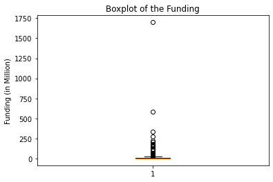

```python
boxp = plt.boxplot(df1.Funds_in_million)
plt.title('Boxplot of the Funding')
plt.ylabel("Funding (in Million)")

plt.show()
```

### Getting Lower fence from Boxplot

```python
lower_fence = boxp['caps'][0].get_data()[1][1]
lower_fence
```

```
0.005
```

```python
upper_fence = boxp['caps'][1].get_data()[1][1]
upper_fence
```

```
22.0
```

### Getting number of outliers

```python
print(f'Number of outliers = {len(df1[df1.Funds_in_million > upper_fence])}')

df1[df1.Funds_in_million > upper_fence]
```

```
Number of outliers = 60
```

|  | Startup | Product | Funding | Event | Result | OperatingState | Funds_in_million |
| --- | --- | --- | --- | --- | --- | --- | --- |
| 6 | 8 Securities | 8securities.com | $29M | Disrupt Beijing 2011 | Finalist | Operating | 29.0 |
| 31 | Anyclip | anyclip.com | $24M | TC50 2009 | Finalist | Operating | 24.0 |
| 40 | Artsy | artsy.net | $50.9M | Disrupt NYC 2010 | Contestant | Operating | 50.9 |
| 49 | Badgeville | badgeville.com | $40M | Disrupt SF 2010 | Finalist | Acquired | 40.0 |
| 56 | Betterment | betterment.com | $205M | Disrupt NYC 2010 | Finalist | Operating | 205.0 |
| 108 | Clickable | clickable.com | $32.5M | TC40 2007 | Finalist | Acquired | 32.5 |
| 113 | Cloudflare | cloudflare.com | $182.1M | Disrupt SF 2010 | Runner up | Operating | 182.1 |
| 128 | Credit Sesame | creditsesame.com | $35.4M | Disrupt SF 2010 | Contestant | Operating | 35.4 |
| 130 | CrowdFlower Inc. | crowdflower.com | $38M | TC50 2009 | Contestant | Operating | 38.0 |
| 132 | Cubic Telecom | cubictelecom.com | $37.1M | TC40 2007 | Contestant | Operating | 37.1 |
| 138 | DataSift | datasift.com | $72M | Disrupt SF 2010 | Finalist | Operating | 72.0 |
| 139 | DataXu | dataxu.com | $64M | TC50 2009 | Contestant | Operating | 64.0 |
| 154 | Dropbox | dropbox.com | $1.7B | TC50 2008 | Contestant | Operating | 1700.0 |
| 166 | Enigma | enigma.io | $34.6M | Disrupt NYC 2013 | Winner | Operating | 34.6 |
| 172 | EverythingMe | everything.me | $35.5M | Disrupt NYC 2011 | Contestant | Closed | 35.5 |
| 179 | Famo.us | famo.us | $30.1M | Disrupt SF 2012 | Contestant | Operating | 30.1 |
| 180 | Farmigo | farmigo.com | $26M | Disrupt SF 2011 | Finalist | Operating | 26.0 |
| 188 | Fitbit | fitbit.com | $66M | TC50 2008 | Finalist | Ipo | 66.0 |
| 191 | Flock | flock.com | $28.3M | TC40 2007 | Contestant | Acquired | 28.3 |
| 209 | Getaround | getaround.com | $103M | Disrupt NYC 2011 | Winner | Operating | 103.0 |
| 213 | Gild | gild.com | $25.9M | Disrupt SF 2010 | Contestant | Acquired | 25.9 |
| 215 | Glide | glide.me | $36.5M | Disrupt NYC 2013 | Audience choice | Operating | 36.5 |
| 225 | Grockit | grockit.com | $44.7M | TC50 2008 | Finalist | Acquired | 44.7 |
| 231 | HackerRank | hackerrank.com | $24.2M | Disrupt SF 2012 | Contestant | Operating | 24.2 |
| 271 | Ionic Security | ionicsecurity.com | $122.4M | Disrupt SF 2012 | Contestant | Operating | 122.4 |
| 276 | IZEA | izea.com | $34.9M | Disrupt NYC 2010 | Contestant | Ipo | 34.9 |
| 279 | Jiff | jiff.com | $67.8M | Disrupt SF 2011 | Contestant | Acquired | 67.8 |
| 282 | Kaltura | kaltura.com | $166.1M | TC40 2007 | Audience choice | Operating | 166.1 |
| 302 | Layer | layer.com | $42.1M | Disrupt SF 2013 | Winner | Operating | 42.1 |
| 305 | LearnVest | learnvest.com | $69M | TC50 2009 | Contestant | Acquired | 69.0 |
| 313 | LiveIntent | liveintent.com | $65.1M | Disrupt NYC 2010 | Audience choice | Operating | 65.1 |
| 325 | Lystable | lystable.com | $25.1M | Disrupt London 2015 | Finalist | Operating | 25.1 |
| 346 | Mint | mint.com | $31.8M | TC40 2007 | Winner | Acquired | 31.8 |
| 389 | OrderWithMe | orderwithme.com | $37M | Disrupt Beijing 2011 | Winner | Operating | 37.0 |
| 393 | Osmo | playosmo.com | $38.5M | Disrupt SF 2013 | Contestant | Operating | 38.5 |
| 394 | Ossia | ossia.com | $25.5M | Disrupt SF 2013 | Runner up | Operating | 25.5 |
| 398 | Owlet Baby Care | owletcare.com | $24M | Hardware Battlefield 2014 | Runner up | Operating | 24.0 |
| 427 | Postmates | postmates.com | $278M | Disrupt SF 2011 | Contestant | Operating | 278.0 |
| 432 | Prism Skylabs | prism.com | $24M | Disrupt SF 2011 | Runner up | Operating | 24.0 |
| 435 | PubMatic | pubmatic.com | $63M | TC40 2007 | Contestant | Operating | 63.0 |
| 460 | Roadie | roadie.com | $25M | Disrupt NYC 2014 | Audience choice | Operating | 25.0 |
| 471 | SeatGeek | seatgeek.com | $160M | TC50 2009 | Contestant | Operating | 160.0 |
| 546 | StyleSeat | styleseat.com | $40M | Disrupt NYC 2011 | Contestant | Operating | 40.0 |
| 555 | Symphony Commerce | symphonycommerce.com | $47.4M | Disrupt NYC 2011 | Contestant | Operating | 47.4 |
| 560 | Talkdesk | talkdesk.com | $24.5M | Disrupt NYC 2012 | Contestant | Operating | 24.5 |
| 581 | TouchPal | touchpal.com | $25M | Disrupt Beijing 2011 | Finalist | Operating | 25.0 |
| 593 | TrueCar | truecar.com | $332.4M | TC50 2008 | Contestant | Ipo | 332.4 |
| 598 | UberConference | uberconference.com | $35M | Disrupt NYC 2012 | Winner | Operating | 35.0 |
| 606 | Upwork | upwork.com | $168.8M | TC50 2009 | Audience choice | Operating | 168.8 |
| 615 | VideoSurf | videosurf.com | $28M | TC50 2008 | Contestant | Acquired | 28.0 |
| 625 | Voxy | voxy.com | $30.8M | Disrupt SF 2010 | Contestant | Operating | 30.8 |
| 643 | Xobni | yahoo.com | $41.8M | TC40 2007 | Contestant | Acquired | 41.8 |
| 644 | Yammer | yammer.com | $142M | TC50 2008 | Winner | Acquired | 142.0 |
| 647 | Yext | yext.com | $117.8M | TC50 2009 | Contestant | Ipo | 117.8 |
| 649 | YouNow | younow.com | $26M | Disrupt SF 2011 | Contestant | Operating | 26.0 |
| 650 | YourMechanic | yourmechanic.com | $28M | Disrupt SF 2012 | Winner | Operating | 28.0 |
| 654 | ZEFR | zefr.com | $62.1M | Disrupt NYC 2010 | Contestant | Operating | 62.1 |
| 656 | Zenefits | zenefits.com | $583.6M | Disrupt NYC 2013 | Finalist | Operating | 583.6 |
| 659 | Zocdoc | zocdoc.com | $223M | TC40 2007 | Contestant | Operating | 223.0 |
| 661 | Zumper | zumper.com | $31.5M | Disrupt SF 2012 | Finalist | Operating | 31.5 |

### Dropping values greater than Upper Fence

```python
df1.drop (df1[df1.Funds_in_million > upper_fence].index, inplace = True)
df1
```

|  | Startup | Product | Funding | Event | Result | OperatingState | Funds_in_million |
| --- | --- | --- | --- | --- | --- | --- | --- |
| 1 | 3DLT | 3dlt.com | $630K | Disrupt NYC 2013 | Contestant | Closed | 0.63 |
| 3 | 3Dprintler | 3dprintler.com | $1M | Disrupt NY 2016 | Audience choice | Operating | 1.00 |
| 5 | 5to1 | 5to1.com | $19.3M | TC50 2009 | Contestant | Acquired | 19.30 |
| 10 | AdhereTech | adheretech.com | $1.8M | Hardware Battlefield 2014 | Contestant | Operating | 1.80 |
| 11 | AdRocket | adrocket.com | $1M | TC50 2008 | Contestant | Closed | 1.00 |
| ... | ... | ... | ... | ... | ... | ... | ... |
| 645 | Yap | yapme.com | $10M | TC40 2007 | Contestant | Closed | 10.00 |
| 646 | YayPay Inc | yaypay.com | $900K | Disrupt London 2015 | Contestant | Operating | 0.90 |
| 657 | Zivity | zivity.com | $8M | TC40 2007 | Contestant | Operating | 8.00 |
| 658 | Zmorph | zmorph3d.com | $1M | - | Audience choice | Operating | 1.00 |
| 660 | Zula | zulaapp.com | $3.4M | Disrupt SF 2013 | Audience choice | Operating | 3.40 |

386 rows × 7 columns

```python
len(df1)
```

```
386
```

### Boxplot after dropping Values

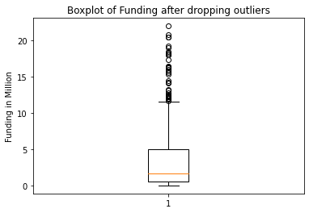

```python
boxp2= plt.boxplot(df1.Funds_in_million)
plt.title ('Boxplot of Funding after dropping outliers')
plt.ylabel ('Funding in Million')
plt.show()
```

### Frequency of Operating State feature

```python
df1.OperatingState.value_counts()
```

```
Operating    275
Closed        56
Acquired      55
Name: OperatingState, dtype: int64
```

### Distribution plot for Funds in Million

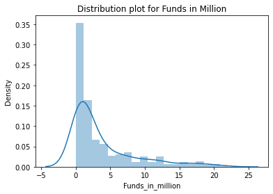

```python
distp = sns.distplot(df1['Funds_in_million'], kde=True, rug=False)
plt.title ('Distribution plot for Funds in Million')
plt.show()
```

### Distribution plots for Funding from companies still operating and companies that closed.

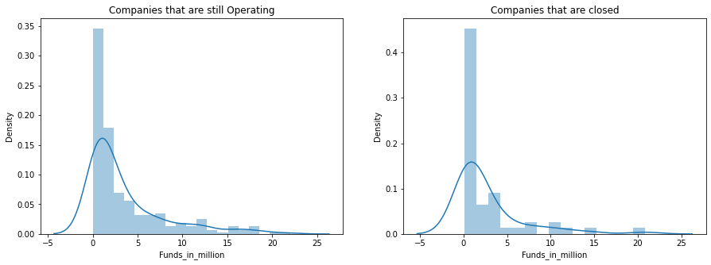

```python
fig, ax = plt.subplots (1, 2)

fig.set_figheight (5)
fig.set_figwidth (15)

sns.distplot(df1.loc[df1.OperatingState == 'Operating', 'Funds_in_million'], ax=ax[0])
sns.distplot(df1.loc[df1.OperatingState == 'Closed', 'Funds_in_million'], ax=ax[1])

ax[0].set_title('Companies that are still Operating')
ax[1].set_title('Companies that are closed')
```

# 4. Statistical Analysis:

### Testing Hypothesis

```python
#Null hypothesis (Ho) = No difference between Means
#Alt hypothesis (Ha) = Difference between the two means
```

```python
from statsmodels.stats.weightstats import ztest

s1= df1.loc[df1.OperatingState == 'Operating', 'Funds_in_million']
s2= df1.loc[df1.OperatingState == 'Closed', 'Funds_in_million']

alpha = .05

t_stat, p_val = ztest(s1,s2)

if p_val <= alpha:
    print ('We Reject the Null Hypothesis as ''Value of P is %1.4f' %p_val, 'which is lower than alpha')
else:
    print ('We Accept the Null Hypothesis as ''Value of P is %1.4f ' %p_val, 'which is greater than alpha')
```

[output not shown]

### Copying Original DataFrame

```python
df2=df1.copy (deep=True)
df2
```

|  | Startup | Product | Funding | Event | Result | OperatingState | Funds_in_million |
| --- | --- | --- | --- | --- | --- | --- | --- |
| 1 | 3DLT | 3dlt.com | $630K | Disrupt NYC 2013 | Contestant | Closed | 0.63 |
| 3 | 3Dprintler | 3dprintler.com | $1M | Disrupt NY 2016 | Audience choice | Operating | 1.00 |
| 5 | 5to1 | 5to1.com | $19.3M | TC50 2009 | Contestant | Acquired | 19.30 |
| 10 | AdhereTech | adheretech.com | $1.8M | Hardware Battlefield 2014 | Contestant | Operating | 1.80 |
| 11 | AdRocket | adrocket.com | $1M | TC50 2008 | Contestant | Closed | 1.00 |
| ... | ... | ... | ... | ... | ... | ... | ... |
| 645 | Yap | yapme.com | $10M | TC40 2007 | Contestant | Closed | 10.00 |
| 646 | YayPay Inc | yaypay.com | $900K | Disrupt London 2015 | Contestant | Operating | 0.90 |
| 657 | Zivity | zivity.com | $8M | TC40 2007 | Contestant | Operating | 8.00 |
| 658 | Zmorph | zmorph3d.com | $1M | - | Audience choice | Operating | 1.00 |
| 660 | Zula | zulaapp.com | $3.4M | Disrupt SF 2013 | Audience choice | Operating | 3.40 |

386 rows × 7 columns

### Frequency distribution of 'Result'

```python
df2.Result.value_counts()
```

```
Contestant         282
Finalist            52
Audience choice     20
Winner              17
Runner up           15
Name: Result, dtype: int64
```

### Percentage of winners that are still operating and percentage of contestants that are still operating

```python
winners = df2.Result.value_counts()['Winner']
contestants = df2.Result.value_counts()['Contestant']

contestants_operating = df2.OperatingState[df2.Result == 'Contestant'].value_counts().loc['Operating']
winners_operating = df2.OperatingState[df2.Result == 'Winner'].value_counts().loc['Operating']

percent_winner_operating = (winners_operating/winners)*100
percent_contestant_operating = (contestants_operating/contestants)*100

print ('Number of Winners is', winners)
print ('Number of contestants is', contestants)
print ('Number of Winners that are operating is', winners_operating)
print ('Number of contestants that are operating is', contestants_operating)
print ('Percentage of Winners that are still operating is %1.2f' %percent_winner_operating,'%')
print ('Percentage of Contestants that are still operating is %1.2f' %percent_contestant_operating,'%')
```

```
Number of Winners is 17
Number of contestants is 282
Number of Winners that are operating is 12
Number of contestants that are operating is 194
Percentage of Winners that are still operating is 70.59 %
Percentage of Contestants that are still operating is 68.79 %
```

### Hypothesis comparing the proportion of companies that are operating between winners and contestants

```python
#Null hypothesis, Ho = proportion of companies that are operating between winners and contestants is same
#Alternate hypothesis, Ha = proportion of companies that are operating between winners and contestants is different
```

```python
from statsmodels.stats.proportion import proportions_ztest

tstat, p_val = proportions_ztest([contestants_operating, winners_operating], [contestants, winners])
alpha = 0.05

if p_val <= alpha:
    print ('We Reject the Null Hypothesis as ''Value of P is %1.4f' %p_val, 'which is lower than alpha')
else:
    print ('We Accept the Null Hypothesis as ''Value of P is %1.4f ' %p_val, 'which is greater than alpha')
```

```
We Accept the Null Hypothesis as Value of P is 0.8767  which is greater than alpha
```

## CONCLUSION: There is not much difference between Winners and Contestants in being Operational

```python
df2.Event.value_counts()
```

```
TC50 2008                    25
TC40 2007                    22
Disrupt NY 2015              21
Disrupt NYC 2013             19
Disrupt SF 2015              19
Disrupt SF 2014              19
TC50 2009                    19
Disrupt SF 2011              19
Disrupt SF 2013              19
Disrupt NYC 2012             19
Disrupt SF 2016              17
Disrupt NY 2016              16
Disrupt NYC 2011             15
Disrupt SF 2012              15
Disrupt NYC 2014             15
Disrupt SF 2010              13
Hardware Battlefield 2016    12
Hardware Battlefield 2014    12
Disrupt London 2015          11
Disrupt NYC 2010             10
Disrupt London 2016          10
Disrupt EU 2014              10
Hardware Battlefield 2015    10
Disrupt EU 2013               9
-                             6
Disrupt Beijing 2011          4
Name: Event, dtype: int64
```

```python
events_disrupt = df1[df1.Event.apply(lambda x: 'Disrupt' in x and int(x[-4:]) > 2012)].Event
events_disrupt
```

```
1         Disrupt NYC 2013
3          Disrupt NY 2016
13         Disrupt SF 2015
14     Disrupt London 2016
16         Disrupt SF 2015
              ...
635        Disrupt NY 2015
641       Disrupt NYC 2013
642        Disrupt SF 2014
646    Disrupt London 2015
660        Disrupt SF 2013
Name: Event, Length: 185, dtype: object
```

### Hypothesis:

#### Null Hypothesis (Ho) = Average funds raised by companies in 3 cities are same

#### Alternate Hypothesis (Ha) = Average funds raised by companies in 3 cities are different

```python
NY_events = df1.loc[events_disrupt[events_disrupt.apply(lambda x: 'NY' in x)].index, 'Funds_in_million']
SF_events = df1.loc[events_disrupt[events_disrupt.apply(lambda x: 'SF' in x)].index, 'Funds_in_million']
EU_events = df1.loc[events_disrupt[events_disrupt.apply(lambda x: 'EU' in x or 'London' in x)].index, 'Funds_in_million']

print(len(NY_events), len(SF_events), len(EU_events))
```

```
71 74 40
```

### Distribution plot comparing the 3 city events

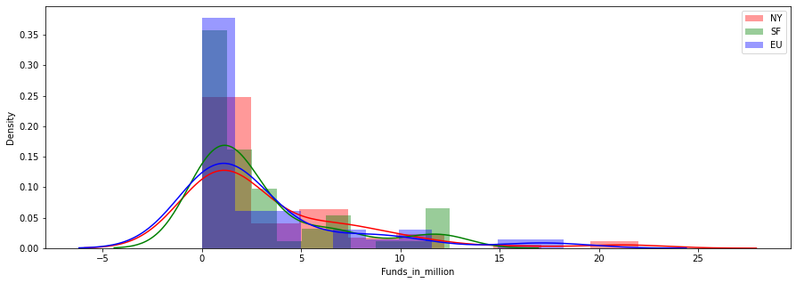

```python
plt.figure (figsize=(15,5))
sns.distplot (NY_events, color = 'Red', label = 'NY')
sns.distplot (SF_events, color = 'Green', label = 'SF')
sns.distplot (EU_events, color = 'blue', label = 'EU')
plt.legend()
plt.show()
```

```python
from scipy.stats import f_oneway

stat, p_val = f_oneway(NY_events, SF_events, EU_events)
alpha= 0.05

if p_val <= alpha:
 print ('We Reject the Null Hypothesis as ''Value of P is %1.4f' %p_val, 'which is lower than alpha')
else:
    print ('We Accept the Null Hypothesis as ''Value of P is %1.4f ' %p_val, 'which is greater than alpha')
```

```
We Accept the Null Hypothesis as Value of P is 0.6284  which is greater than alpha
```

### 1. As the difference between the funds raised by the 3 cities is not very significant, We Accept the Null Hypothesis

### 2. We can also see that the distribution of the 3 cities is also same.

## OBSERVATION ON IMPROVEMENT

#### 1. Volume is the base of Big Data, and the more the merrier. There were 60 outliers in the Funding section which had to be dropped.

#### 2. I would suggest to follow a single unit of measurement for currency, as it would yield better results.

#### 3. It is crucial that data is captured at a fast pace as it helps yield significant results. Stale data will give results that may not be useful in future.

#### 4. Variety must also be taken care of as it is better to capture anything and everything of value in the business ecosystem. Data that look like it has no immediate value, can yield great results when processed correctly.

#### 5. Veracity, or Trustworthiness of data holds utmost importance as without it models built on the data will not be of true value

#### 6. Value can be deemed as the most important aspect. If the Big Data system cannot derive value out of the whole exercise it isn’t worth involving it in the business.